# EDS 232: Lab 2 - Clustering

Paloma Cartwright

2022-02-06

# 1. Clustering

This lab was set-up using the `iris` dataset but I will switch the dataset and use `palmerpenguins` instead but with the same applications.

## 1.1 K-Means Clustering

k-means clustering specifies the number of clusters needed. The algorithm randomly assigns each observation to a cluster and finds the centroid of each cluster. Then the algorithm: - Reassigns data points to the cluster whose centriod is closest - Calculates the new centriod of each cluster.

### 1.1.1 Load and plot the `penguins` dataset

```r
data(penguins)

if(interactive())
  help(penguins)

datatable(penguins)
```

|  | species | island | bill_length_mm | bill_depth_mm | flipper_length_mm | body_mass_g | sex | year |
| --- | --- | --- | --- | --- | --- | --- | --- | --- |
| 1 | Adelie | Torgersen | 39.1 | 18.7 | 181 | 3750 | male | 2007 |
| 2 | Adelie | Torgersen | 39.5 | 17.4 | 186 | 3800 | female | 2007 |
| 3 | Adelie | Torgersen | 40.3 | 18 | 195 | 3250 | female | 2007 |
| 4 | Adelie | Torgersen |  |  |  |  |  | 2007 |
| 5 | Adelie | Torgersen | 36.7 | 19.3 | 193 | 3450 | female | 2007 |
| 6 | Adelie | Torgersen | 39.3 | 20.6 | 190 | 3650 | male | 2007 |
| 7 | Adelie | Torgersen | 38.9 | 17.8 | 181 | 3625 | female | 2007 |
| 8 | Adelie | Torgersen | 39.2 | 19.6 | 195 | 4675 | male | 2007 |
| 9 | Adelie | Torgersen | 34.1 | 18.1 | 193 | 3475 |  | 2007 |
| 10 | Adelie | Torgersen | 42 | 20.2 | 190 | 4250 |  | 2007 |

[output cut: 334 more lines]

```r
penguins <- penguins %>%
  drop_na()

skim(penguins)
```

Data summary

| Name | penguins |
| --- | --- |
| Number of rows | 333 |
| Number of columns | 8 |
| _______________________ |  |
| Column type frequency: |  |
| factor | 3 |
| numeric | 5 |
| ________________________ |  |
| Group variables | None |

**Variable type: factor**

| skim_variable | n_missing | complete_rate | ordered | n_unique | top_counts |
| --- | --- | --- | --- | --- | --- |
| species | 0 | 1 | FALSE | 3 | Ade: 146, Gen: 119, Chi: 68 |
| island | 0 | 1 | FALSE | 3 | Bis: 163, Dre: 123, Tor: 47 |
| sex | 0 | 1 | FALSE | 2 | mal: 168, fem: 165 |

**Variable type: numeric**

| skim_variable | n_missing | complete_rate | mean | sd | p0 | p25 | p50 | p75 | p100 | hist |
| --- | --- | --- | --- | --- | --- | --- | --- | --- | --- | --- |
| bill_length_mm | 0 | 1 | 43.99 | 5.47 | 32.1 | 39.5 | 44.5 | 48.6 | 59.6 | ▃▇▇▆▁ |
| bill_depth_mm | 0 | 1 | 17.16 | 1.97 | 13.1 | 15.6 | 17.3 | 18.7 | 21.5 | ▅▆▇▇▂ |
| flipper_length_mm | 0 | 1 | 200.97 | 14.02 | 172.0 | 190.0 | 197.0 | 213.0 | 231.0 | ▂▇▃▅▃ |
| body_mass_g | 0 | 1 | 4207.06 | 805.22 | 2700.0 | 3550.0 | 4050.0 | 4775.0 | 6300.0 | ▃▇▅▃▂ |
| year | 0 | 1 | 2008.04 | 0.81 | 2007.0 | 2007.0 | 2008.0 | 2009.0 | 2009.0 | ▇▁▇▁▇ |

In using `palmerpenguins` instead of `iris`, I will be using `bill_length_mm` instead of `Petal.Length` and `bill_depth_mm` instead of `Petal.Width`.

#### 1 2a.Cluster.geom_point()

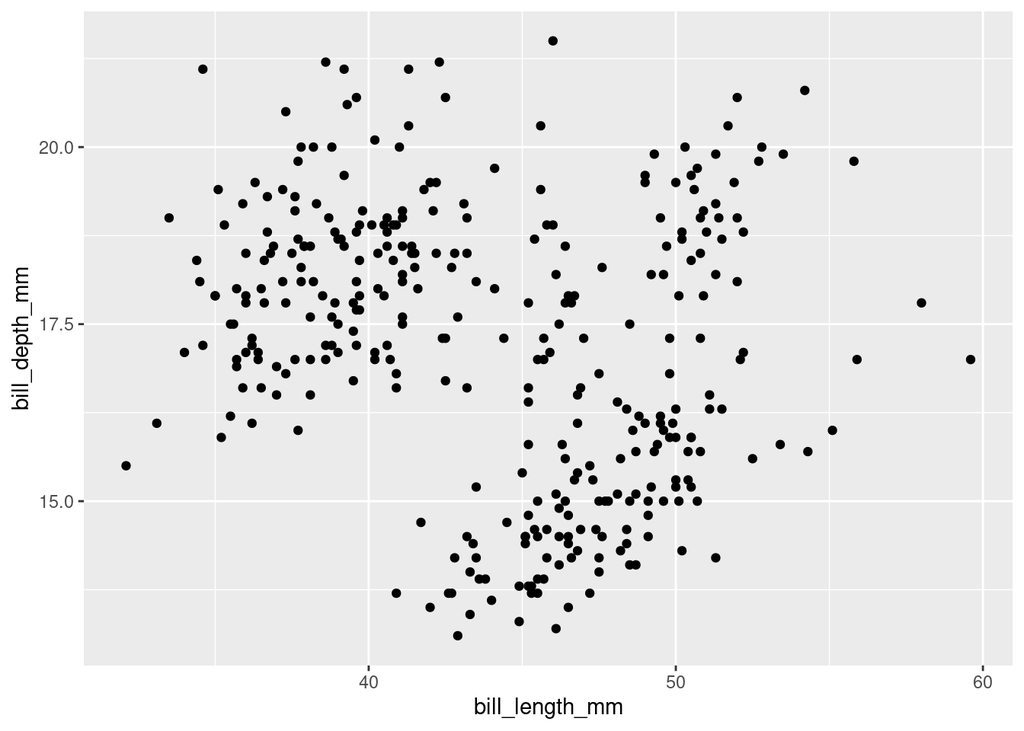

```r
# plot bill length vs depth, ignoring species
ggplot(penguins, aes(bill_length_mm, bill_depth_mm)) +
  geom_point()
```

#### 2 2a.Cluster.geom_point()

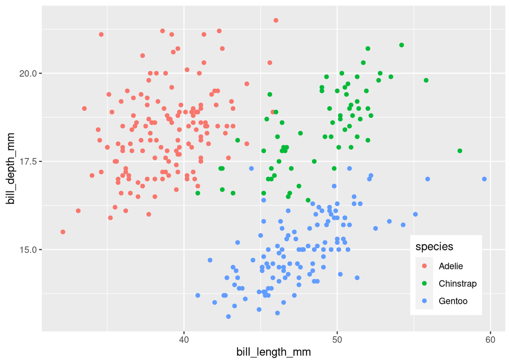

```r
#plot bill length vs depth, color by species

legend_pos <- theme(
  legend.position = c(0.95, 0.05),
  legend.justification = c("right", "bottom"),
  legend.box.just = "right"
)

ggplot(penguins, aes(x = bill_length_mm, y = bill_depth_mm, color = species)) +
  geom_point() +
  legend_pos
```

### 1.1.2 Cluster `penguins` using `kmeans()`

#### 3 2a.Cluster.kmeans()

```r
k <- 3 # number of clusters
penguins_k <- kmeans(
  penguins %>%
    select(bill_length_mm, bill_depth_mm),
  centers = k
)

penguins_k
```

```
## K-means clustering with 3 clusters of sizes 136, 85, 112
##
## Cluster means:
##   bill_length_mm bill_depth_mm
## 1       38.42426      18.27794
## 2       50.90353      17.33647
## 3       45.50982      15.68304
##
## Clustering vector:
##   [1] 1 1 1 1 1 1 1 1 1 1 1 1 1 1 3 1 1 1 1 1 1 1 1 1 1 1 1 1 1 1 1 1 1 1 1 1 1
##  [38] 1 3 1 1 1 1 1 1 1 1 1 1 1 1 1 1 1 1 1 1 1 1 1 1 1 1 1 1 1 1 3 1 3 1 1 1 1
##  [75] 1 3 1 1 1 1 1 1 1 1 1 1 1 1 1 1 1 1 1 3 1 1 1 1 1 1 1 1 1 3 1 3 1 1 1 3 1
## [112] 1 1 1 1 1 1 1 1 1 1 1 1 3 1 3 1 1 1 1 1 1 1 1 1 1 1 1 1 1 1 1 1 1 1 1 3 2
## [149] 3 2 3 3 3 3 3 3 3 2 3 3 3 2 3 2 3 2 2 3 3 3 3 3 3 3 2 3 3 3 2 2 2 3 3 3 2
## [186] 3 2 3 2 2 3 3 2 3 3 3 3 3 2 3 3 3 3 3 2 3 3 3 2 3 2 2 3 2 3 3 3 3 3 2 3 2
## [223] 3 3 2 2 3 2 3 2 3 2 3 2 3 2 3 2 3 2 2 3 3 2 3 2 3 2 3 3 2 3 3 2 2 3 2 3 2
## [260] 2 3 3 2 3 2 3 2 2 3 2 3 3 2 3 2 3 2 3 2 3 2 2 2 3 2 3 2 3 2 3 2 2 2 3 2 1
## [297] 2 3 2 2 3 3 2 3 2 2 3 2 3 2 2 2 2 2 2 3 2 3 2 3 2 3 2 2 3 2 3 3 2 3 2 2 2
##
## Within cluster sum of squares by cluster:
## [1] 904.9838 617.9859 742.0970
##  (between_SS / total_SS =  79.8 %)
##
## Available components:
##
## [1] "cluster"      "centers"      "totss"        "withinss"     "tot.withinss"
## [6] "betweenss"    "size"         "iter"         "ifault"
```

```r
# compare clusters with species to find out which were not used to cluster

table(penguins_k$cluster, penguins$species)
```

```
##
##     Adelie Chinstrap Gentoo
##   1    135         1      0
##   2      0        40     45
##   3     11        27     74
```

### **Question**

How many observations could be considered “misclassified” if expecting bill length and depth to differentiate between species?

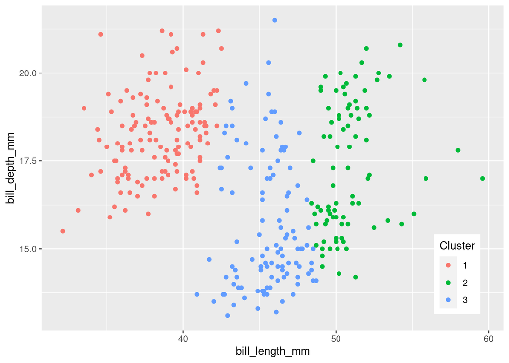

```r
# extract cluster assignment per observation

Cluster = factor(penguins_k$cluster)

ggplot(penguins, aes(x = bill_length_mm, bill_depth_mm, color = Cluster))+
  geom_point() +
  legend_pos
```

### 1.1.3 Plot Voronoi diagram of clustered `penguins`

#### Bounding Box

```r
# define the bounding box for geom_voronoi()
# define bounding box for geom_voronoi()
xr <- extendrange(range(penguins$bill_length_mm), f=0.1)
yr <- extendrange(range(penguins$bill_depth_mm), f=0.1)
box <- tribble(
  ~bill_length_mm, ~bill_depth_mm, ~group,
  xr[1], yr[1], 1,
  xr[1], yr[2], 1,
  xr[2], yr[2], 1,
  xr[2], yr[1], 1,
  xr[1], yr[1], 1) %>%
  data.frame()
```

#### Voronoi for k = 3

#### 5 2a.Cluster.geom_voronoi()

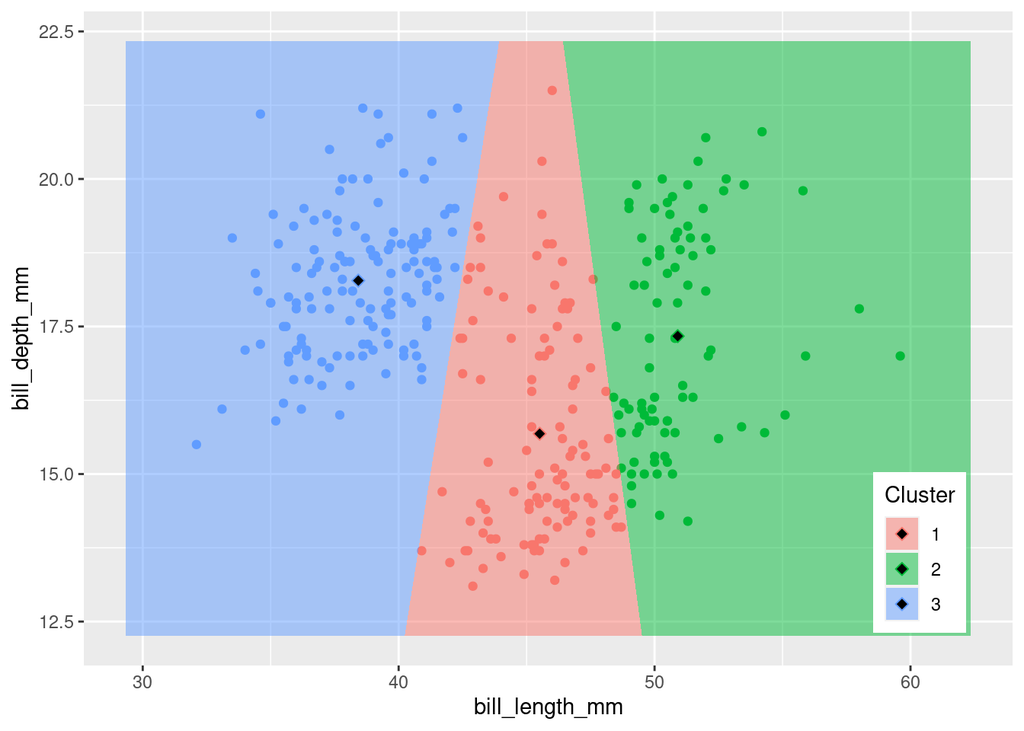

```r
#cluster using kmeans()

k <- 3
penguins_k <- kmeans(
  penguins %>%
    select(bill_length_mm, bill_depth_mm),
  centers = k)

#extract cluster assignment per observation
Cluster = factor(penguins_k$cluster)

#extract cluster centers

ctrs <- as.data.frame(penguins_k$centers) %>%
  mutate(
    Cluster = factor(1:k)
  )

#plot points with voronoi diagram showin the nearest centriod
ggplot(penguins, aes(bill_length_mm, bill_depth_mm, color = Cluster)) +
  geom_point() +
  legend_pos +
  geom_voronoi(
    data = ctrs,
    aes(fill = Cluster), color = NA, alpha = 0.5, outline = box
  ) +
  geom_point(
    data = ctrs, pch = 23, cex = 2, fill = "black"
  )
```

#### Voronoi for k = 2

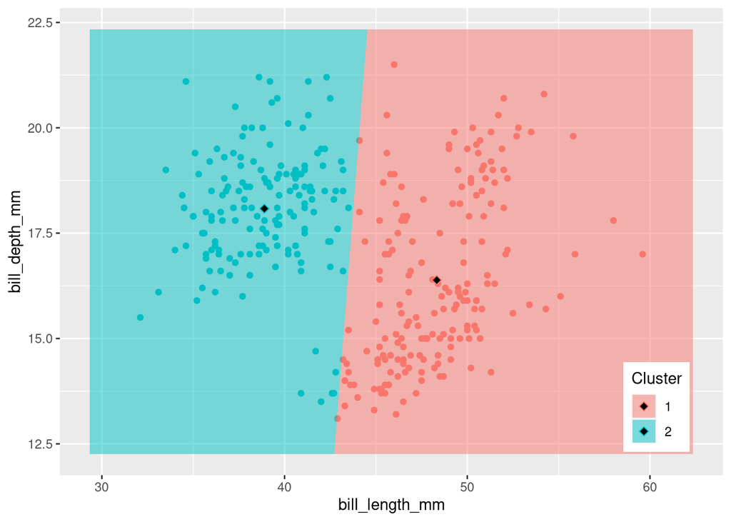

```r
#cluster using kmeans()

k <- 2
penguins_k <- kmeans(
  penguins %>%
    select(bill_length_mm, bill_depth_mm),
  centers = k)

#extract cluster assignment per observation
Cluster = factor(penguins_k$cluster)

#extract cluster centers

ctrs <- as.data.frame(penguins_k$centers) %>%
  mutate(
    Cluster = factor(1:k)
  )

#plot points with voronoi diagram showin the nearest centriod
ggplot(penguins, aes(bill_length_mm, bill_depth_mm, color = Cluster)) +
  geom_point() +
  legend_pos +
  geom_voronoi(
    data = ctrs,
    aes(fill = Cluster), color = NA, alpha = 0.5, outline = box
  ) +
  geom_point(
    data = ctrs, pch = 23, cex = 2, fill = "black"
  )
```

#### Voronoi for k = 8

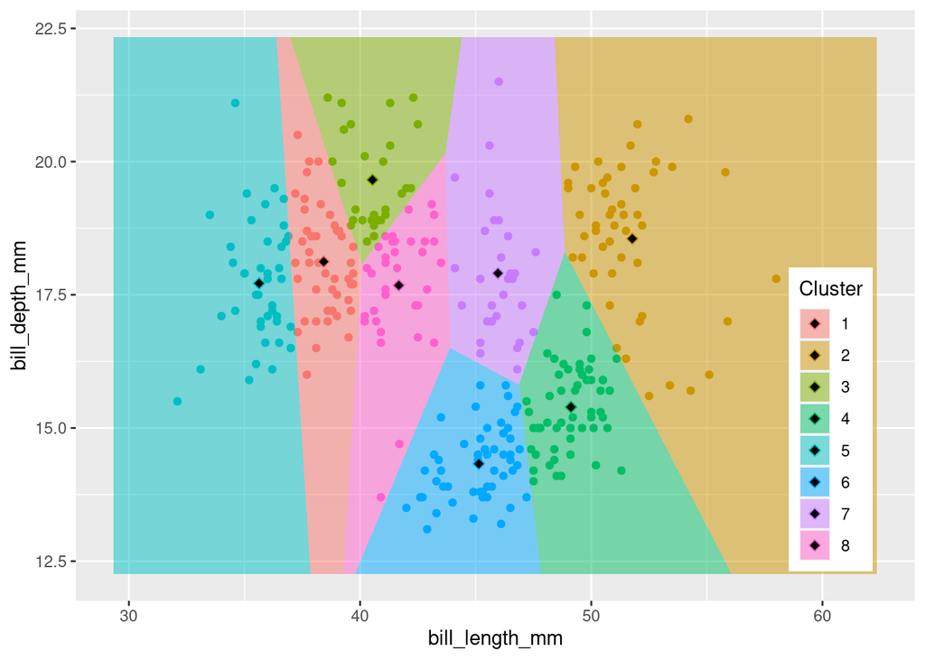

```r
#cluster using kmeans()

k <- 8
penguins_k <- kmeans(
  penguins %>%
    select(bill_length_mm, bill_depth_mm),
  centers = k)

#extract cluster assignment per observation
Cluster = factor(penguins_k$cluster)

#extract cluster centers

ctrs <- as.data.frame(penguins_k$centers) %>%
  mutate(
    Cluster = factor(1:k)
  )

#plot points with voronoi diagram showin the nearest centriod
ggplot(penguins, aes(bill_length_mm, bill_depth_mm, color = Cluster)) +
  geom_point() +
  legend_pos +
  geom_voronoi(
    data = ctrs,
    aes(fill = Cluster), color = NA, alpha = 0.5, outline = box
  ) +
  geom_point(
    data = ctrs, pch = 23, cex = 2, fill = "black"
  )
```

## 1.2 Hierarchical Clustering

### 1.2.1 Load the `dune` dataset

```r
#load the dune dataset from the vegan package
data("dune")

if(interactive())
  help(dune)
```

### **Question**

What are the rows and columns composed of in the dune data frame? The rows in the `dune` data frame are sites and the columns are individual species.

### 1.2.2 Calculate Ecological Distances on `sites`

```r
sites <- tribble(
  ~site, ~sp1, ~sp2, ~sp3,
    "A",    1,    1,    0,
    "B",    5,    5,    0,
    "C",    0,    0,    1) %>%
  column_to_rownames("site")
sites
```

```
##   sp1 sp2 sp3
## A   1   1   0
## B   5   5   0
## C   0   0   1
```

```r
sites_manhattan <- vegdist(sites, method = "manhattan")
sites_manhattan
```

```
##    A  B
## B  8
## C  3 11
```

```r
sites_euclidean <- vegdist(sites, method = "euclidean")
sites_euclidean
```

```
##          A        B
## B 5.656854
## C 1.732051 7.141428
```

```r
sites_bray <- vegdist(sites, method = "bray")
sites_bray
```

```
##           A         B
## B 0.6666667
## C 1.0000000 1.0000000
```

#### 6 2a.Cluster.vegdist() **Question**

The euclidean difference is calculated by measuring the distance between each of the sites. The Bray Curtis distance however is calculated from the differences in the abundance of each species, with a distance of 1 meaning the species are completely different.

### 1.2.3 Bray-Curtis Dissimilarity on `sites`

Let’s take a closer look at the [Bray-Curtis Dissimilarity](https://en.wikipedia.org/wiki/Bray%E2%80%93Curtis_dissimilarity) distance:

$$B_{ij} = 1 - \frac{2C_{ij}}{S_i + S_j}$$

- $B_{ij}$: Bray-Curtis dissimilarity value between sites $i$ and $j$.  
  1 = completely dissimilar (no shared species); 0 = identical.
- $C_{ij}$: sum of the lesser counts $C$ for shared species common to both sites $i$ and $j$
- $S_{i OR j}$: sum of all species counts $S$ for the given site $i$ or $j$

So to calculate Bray-Curtis for the example `sites`:

- $B_{AB} = 1 - \frac{2 * (1 + 1)}{2 + 10} = 1 - 4/12 = 1 - 1/3 = 0.667$
- $B_{AC} = 1 - \frac{2 * 0}{2 + 1} = 1$
- $B_{BC} = 1 - \frac{2 * 0}{10 + 1} = 1$

### 1.2.4 Agglomerative hierarchical clustering on `dune`

#### 7 2a.Cluster.as.matrix()

#### 8 2a.Cluster.hclust()

```r
d <- vegdist(dune, method = "bray")
dim(d)
```

```r
as.matrix(d)[1:5, 1:5]
```

```
##           1         2         3         4         5
## 1 0.0000000 0.4666667 0.4482759 0.5238095 0.6393443
## 2 0.4666667 0.0000000 0.3414634 0.3563218 0.4117647
## 3 0.4482759 0.3414634 0.0000000 0.2705882 0.4698795
## 4 0.5238095 0.3563218 0.2705882 0.0000000 0.5000000
## 5 0.6393443 0.4117647 0.4698795 0.5000000 0.0000000
```

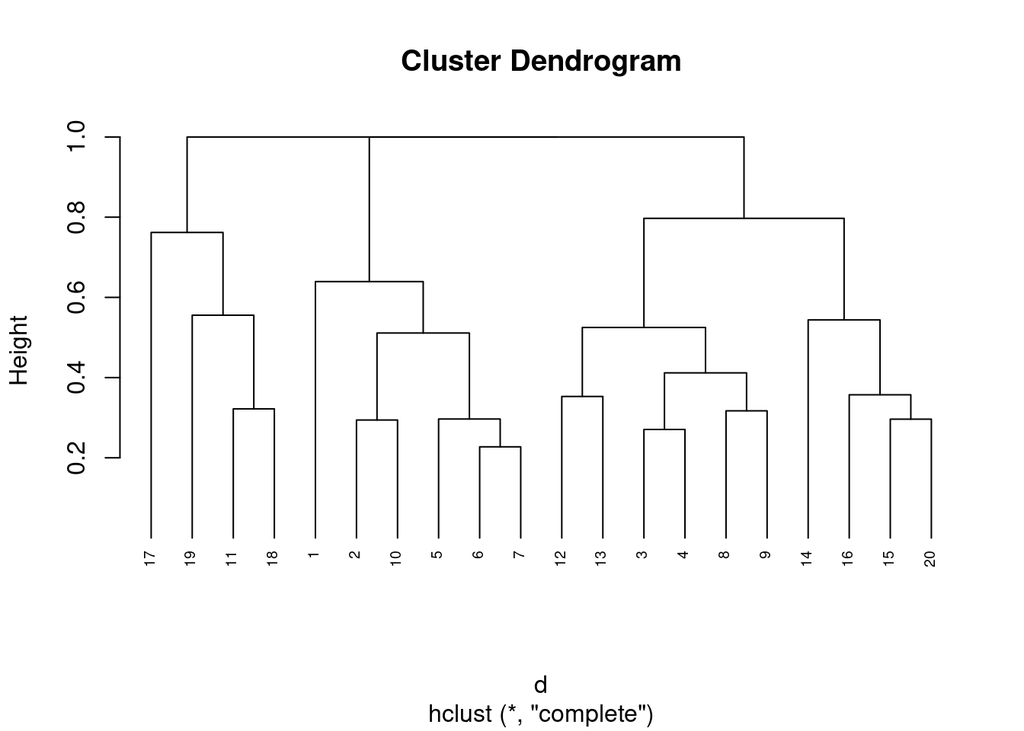

```r
# Hierarchical clustering using complete linkage
hc1 <- hclust(d, method = "complete")

plot(hc1, cex = 0.6, hang = -1)
```

#### 9 2a.Cluster.hclust() **Question**

`vegdist()` comes before `hclust()` because it created the dissimilarity matrix to be plotted in the hierarchical clustering function.

#### 10 2a.Cluster.agnes()

```r
# Hierarchical clustering using agnes
hc2 <- agnes(dune, method = "complete")
hc2$ac
```

```
## [1] 0.5398129
```

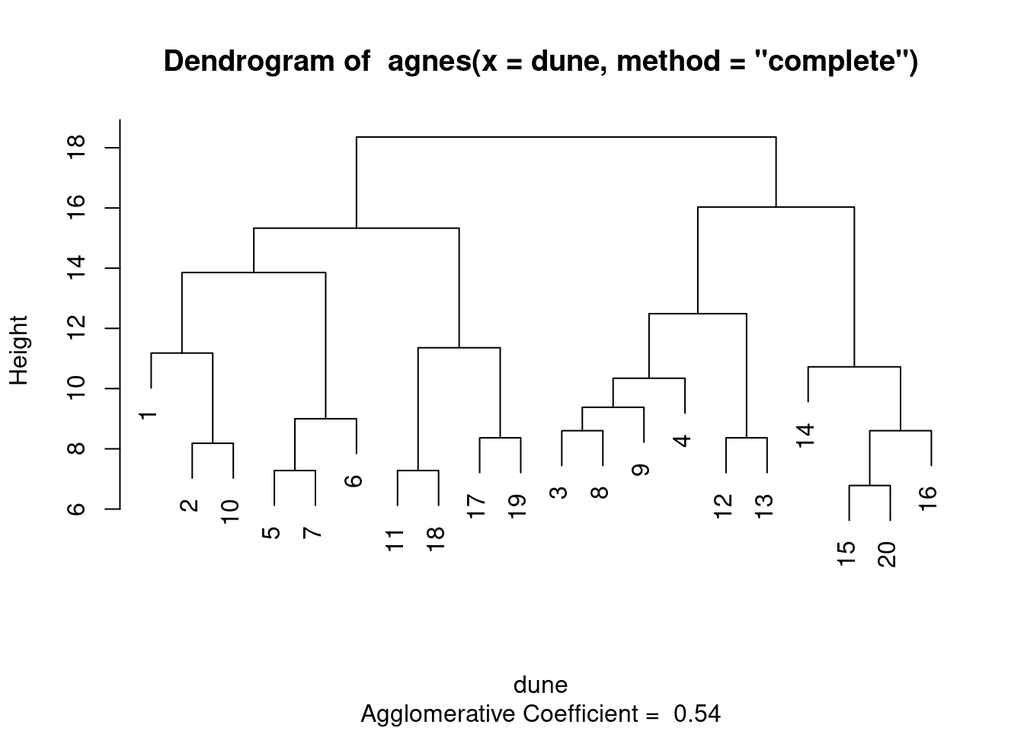

```r
plot(hc2, which.plot = 2)
```

#### 11 2a.Cluster.agnes() **Question**

`hclust()` differs from agnes because it clusters on a set of dissimilarities whereas `agnes()` computes agglomerative hierarchical clustering.

#### 12 2a.Cluster.ac()

```r
# methods to assess

m <- c("average", "single", "complete", "ward")
names(m) <- c("average", "sinlge", "complete", "ward")

#function to compute coefficient
ac <- function(x){
  agnes(dune, method = x)$ac
}

#get agglomerative coefficient for each linkage method
purrr::map_dbl(m, ac)
```

```
##   average    sinlge  complete      ward
## 0.4067153 0.2007896 0.5398129 0.6939994
```

#### 13 2a.Cluster.agnes() **Question**

The best model in terms of the agglomerative coefficient is the ward model.

```r
# Compute ward linkage clustering with agnes
hc3 <- agnes(dune, method = "ward")

hc3$ac
```

```
## [1] 0.6939994
```

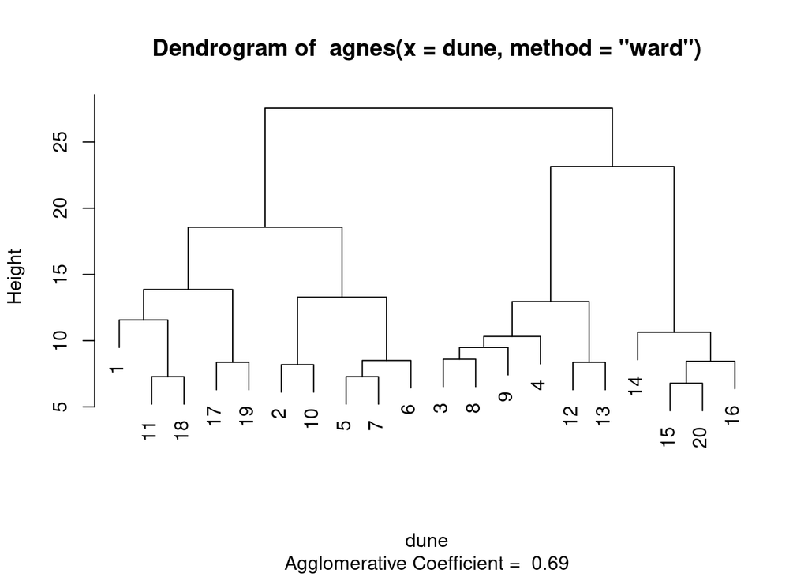

```r
plot(hc3, which.plot = 2)
```

### 1.2.5 Divisive hierarchical clustering on `dune`

#### 14 2a.Cluster.diana()

```r
#compute divisive hierarchical clustering
hc4 <- diana(dune)

# Divise coefficient; amount of clustering structure found
hc4$dc
```

```
## [1] 0.5287677
```

#### 15 2a.Cluster.diana()

`agnes()` is agglomerative clustering but `diana()` does not and instead does divisive hierarchical clustering.

### 1.2.6 Determining optimal clusters

#### 16 2a.Cluster.fviz_nbclust()

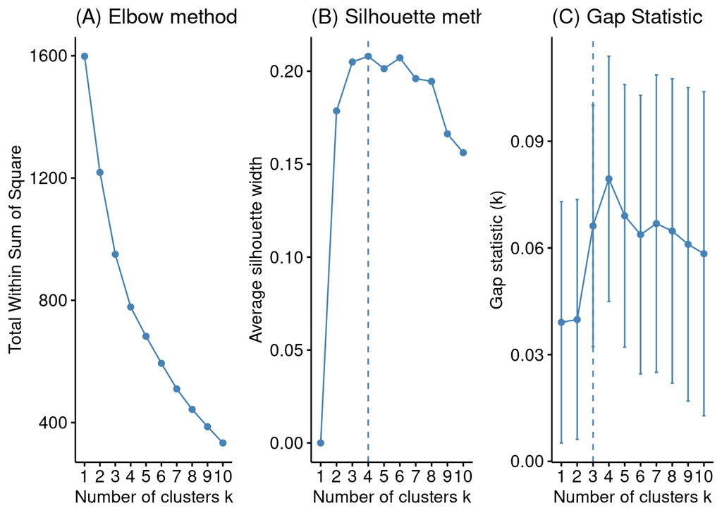

```r
p1 <- fviz_nbclust(dune, FUN = hcut, method = "wss", k.max = 10) +
  ggtitle("(A) Elbow method")

p2 <- fviz_nbclust(dune, FUN = hcut, method = "silhouette", k.max = 10) +
  ggtitle("(B) Silhouette method")

p3 <- fviz_nbclust(dune, FUN = hcut, method = "gap_stat", k.max = 10) +
  ggtitle("(C) Gap Statistic")

# display plots side by side
gridExtra::grid.arrange(p1, p2, p3, nrow = 1)
```

#### 17 2a.Cluster.fviz_dend() **Question**

Since A has no dashed line, I compared the other two methods. The Silhouette method gives us an optiimal number of clusters as 4 whereas the Gap Statistic has one less cluster in the optimal number at 3.

### 1.2.7 Working with dendrograms

[figure not shown]

```r
# construct dendrogram for the Ames housing example

hc5 <- hclust(d, method = "ward.D2")
dend_plot <- fviz_dend(hc5)
dend_data <- attr(dend_plot, "dendrogram")
dend_cuts <- cut(dend_data, h = 8)
fviz_dend(dend_cuts$lower[[2]])
```

```r
# Ward's method
hc5 <- hclust(d, method = "ward.D2")

# Cut tree into 4 groups
k = 4
sub_grp <- cutree(hc5, k)

#Number of members in each cluster
table(sub_grp)
```

```
## sub_grp
## 1 2 3 4
## 8 6 4 2
```

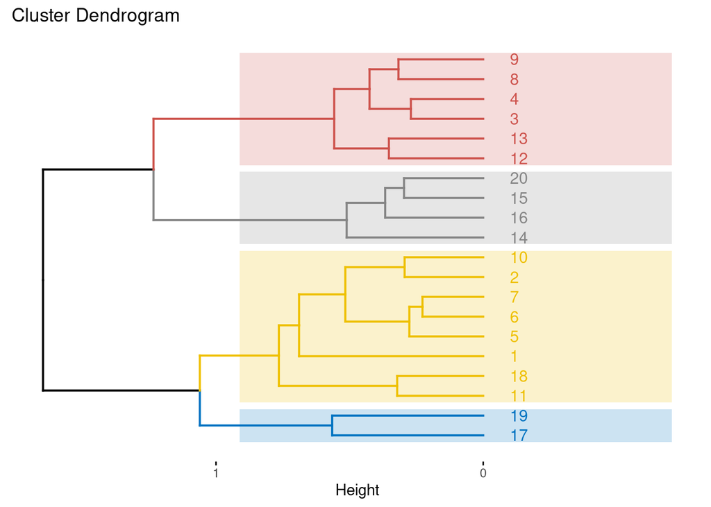

```r
# Plot the full dendogram
fviz_dend(
  hc5,
  k = k,
  horiz = T,
  rect = T,
  rect_fill = T,
  rect_border = "jco",
  k_colors = "jco"
)
```

#### 18 2a.Cluster.fviz_dend() **Question**

In dendrograms, the biggest determinant of relatedness between observations is the height of their shared connection.

# 2. Ordination

In this lab, you will play with unsupervised classification techniques while working with ecological community datasets.

- Ordination orders sites near each other based on similarity. It is a multivariate analysis technique used to effectively collapse dependent axes into fewer dimensions, i.e. dimensionality reduction.
  - Principal Components Analyses (PCA) is the most common and oldest technique that assumes linear relationships between axes. You will follow a non-ecological example from [Chapter 17 Principal Components Analysis](https://bradleyboehmke.github.io/HOML/pca.html) | Hands-On Machine Learning with R to learn about this commonly used technique.
  - Non-metric MultiDimensional Scaling (NMDS) allows for non-linear relationships. This ordination technique is implemented in the R package `vegan`. You’ll use an ecological dataset, species and environment from lichen pastures that reindeer forage upon, with excerpts from the vegantutor vignette (source) to apply these techniques:
    - Unconstrained ordination on species using NMDS;
    - Overlay with environmental gradients; and
    - Constrained ordination on species and environmnent using another ordination technique, canonical correspondence analysis (CCA).

## Principal Components Analysis (PCA)

```r
# get data
url <- "https://koalaverse.github.io/homlr/data/my_basket.csv"
my_basket <- readr::read_csv(url)
dim(my_basket)
```

```
## [1] 2000   42
```

```r
my_basket
```

```
## # A tibble: 2,000 × 42
##    `7up` lasagna pepsi   yop red.wine cheese   bbq bulmers mayonnaise horlics
##    <dbl>   <dbl> <dbl> <dbl>    <dbl>  <dbl> <dbl>   <dbl>      <dbl>   <dbl>
##  1     0       0     0     0        0      0     0       0          0       0
##  2     0       0     0     0        0      0     0       0          0       0
##  3     0       0     0     0        0      0     0       0          0       0
##  4     0       0     0     2        1      0     0       0          0       0
##  5     0       0     0     0        0      0     0       2          0       0
##  6     0       0     0     0        0      0     0       0          0       0
##  7     1       1     0     0        0      0     1       0          0       0
##  8     0       0     0     0        0      0     0       0          0       0
##  9     0       1     0     0        0      0     0       0          0       0
## 10     0       0     0     0        0      0     0       0          0       2
## # … with 1,990 more rows, and 32 more variables: chicken.tikka <dbl>,
## #   milk <dbl>, mars <dbl>, coke <dbl>, lottery <dbl>, bread <dbl>,
## #   pizza <dbl>, sunny.delight <dbl>, ham <dbl>, lettuce <dbl>,
## #   kronenbourg <dbl>, leeks <dbl>, fanta <dbl>, tea <dbl>, whiskey <dbl>,
## #   peas <dbl>, newspaper <dbl>, muesli <dbl>, white.wine <dbl>, carrots <dbl>,
## #   spinach <dbl>, pate <dbl>, instant.coffee <dbl>, twix <dbl>,
## #   potatoes <dbl>, fosters <dbl>, soup <dbl>, toad.in.hole <dbl>, …
```

## Performing PCA in R

#### 19 2b.Community.h2o.prcomp()

```r
h2o.no_progress()  # turn off progress bars for brevity
h2o.init(max_mem_size = "5g")  # connect to H2O instance
```

[output not shown]

```r
# convert data to h2o object
my_basket.h2o <- as.h2o(my_basket)

ncol(my_basket.h2o)
```

```
## [1] 42
```

```r
# run PCA
my_pca <- h2o.prcomp(
  training_frame = my_basket.h2o,
  pca_method = "GramSVD",
  k = ncol(my_basket.h2o),
  transform = "STANDARDIZE",
  impute_missing = TRUE,
  max_runtime_secs = 1000)
my_pca
```

```
## Model Details:
## ==============
##
## H2ODimReductionModel: pca
## Model ID:  PCA_model_R_1643260067821_196
## Importance of components:
##                             pc1      pc2      pc3      pc4      pc5      pc6
## Standard deviation     1.513919 1.473768 1.459114 1.440635 1.435279 1.411544
## Proportion of Variance 0.054570 0.051714 0.050691 0.049415 0.049048 0.047439
## Cumulative Proportion  0.054570 0.106284 0.156975 0.206390 0.255438 0.302878
##                             pc7      pc8      pc9     pc10     pc11     pc12
## Standard deviation     1.253307 1.026387 1.010238 1.007253 0.988724 0.985320
## Proportion of Variance 0.037400 0.025083 0.024300 0.024156 0.023276 0.023116
## Cumulative Proportion  0.340277 0.365360 0.389659 0.413816 0.437091 0.460207
##                            pc13     pc14     pc15     pc16     pc17     pc18
## Standard deviation     0.970453 0.964303 0.951610 0.947978 0.944826 0.932943
## Proportion of Variance 0.022423 0.022140 0.021561 0.021397 0.021255 0.020723
## Cumulative Proportion  0.482630 0.504770 0.526331 0.547728 0.568982 0.589706
##                            pc19     pc20     pc21     pc22     pc23     pc24
## Standard deviation     0.931745 0.924207 0.917106 0.908494 0.903247 0.898109
## Proportion of Variance 0.020670 0.020337 0.020026 0.019651 0.019425 0.019205
## Cumulative Proportion  0.610376 0.630713 0.650739 0.670390 0.689815 0.709020
##                            pc25     pc26     pc27     pc28     pc29     pc30
## Standard deviation     0.894277 0.876167 0.871809 0.865912 0.855036 0.845130
## Proportion of Variance 0.019041 0.018278 0.018096 0.017852 0.017407 0.017006
## Cumulative Proportion  0.728061 0.746339 0.764436 0.782288 0.799695 0.816701
##                            pc31     pc32     pc33     pc34     pc35     pc36
## Standard deviation     0.842818 0.837655 0.826422 0.818532 0.813796 0.804380
## Proportion of Variance 0.016913 0.016706 0.016261 0.015952 0.015768 0.015405
## Cumulative Proportion  0.833614 0.850320 0.866581 0.882534 0.898302 0.913707
##                            pc37     pc38     pc39     pc40     pc41     pc42
## Standard deviation     0.796073 0.793781 0.780615 0.778612 0.763433 0.749696
## Proportion of Variance 0.015089 0.015002 0.014509 0.014434 0.013877 0.013382
## Cumulative Proportion  0.928796 0.943798 0.958307 0.972741 0.986618 1.000000
##
##
## H2ODimReductionMetrics: pca
##
## No model metrics available for PCA
```

#### 20 2b.Community.h2o.prcomp() **Question**

“GramSVD” is used over the “GLRM” method because the data is mostly numeric and GLRM is better for categorical variables.

#### 21 2b.Community.h2o.prcomp() **Question**

There were 42 initial principal components chosen which was the number of columns in the input data.

#### 22 2b.Community.geom_point()

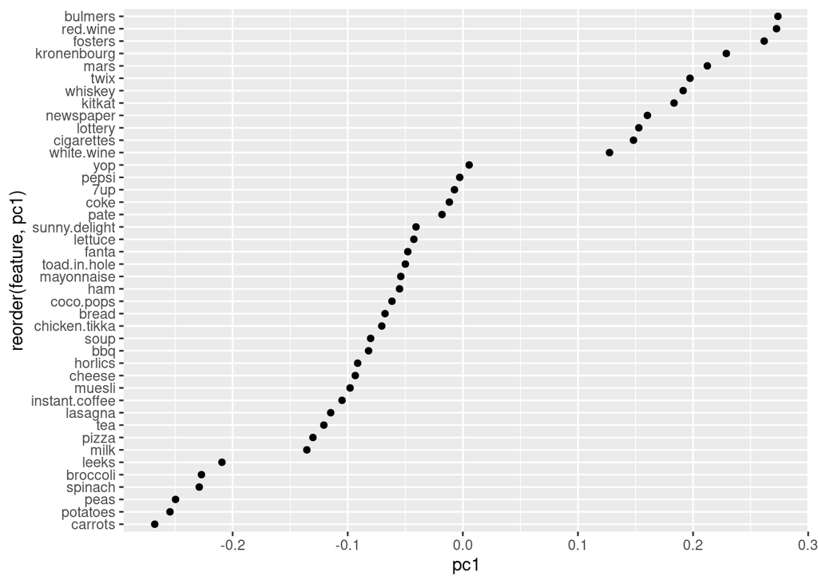

```r
my_pca@model$eigenvectors %>%
  as.data.frame() %>%
  mutate(feature = row.names(.)) %>%
  ggplot(aes(pc1, reorder(feature, pc1))) +
  geom_point()
```

#### 23 2b.Community.geom_point() **Question**

Adult beverages like alcohol contribute the most to PC1.

#### 24. 2b.Community.geom_text()

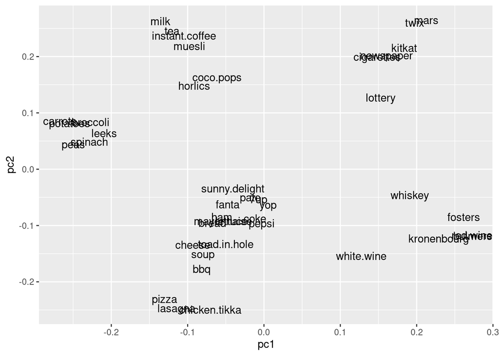

```r
my_pca@model$eigenvectors %>%
  as.data.frame() %>%
  mutate(feature = row.names(.)) %>%
  ggplot(aes(pc1, pc2, label = feature)) +
  geom_text()
```

### Eigenvalue Criterion

#### 26 2b.Community.facet_wrap()

```r
# Compute eigenvalues
eigen <- my_pca@model$importance["Standard deviation", ] %>%
  as.vector() %>%
  .^2

# Sum of all eigenvalues equals number of variables
sum(eigen)
```

```
## [1] 42
```

```r
# Find PCs where the sum of eignvalues is greater than or equal to 1
which(eigen >= 1)
```

```
##  [1]  1  2  3  4  5  6  7  8  9 10
```

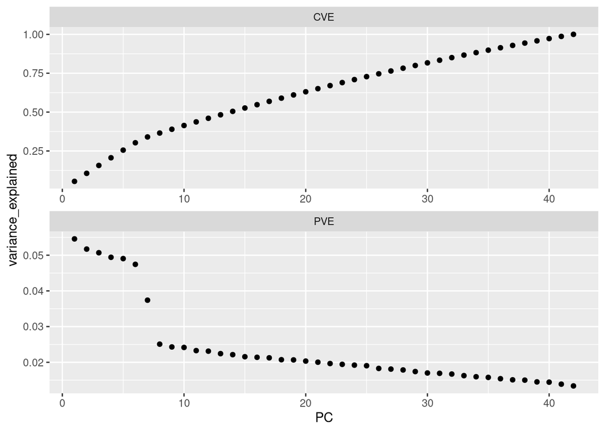

```r
# Extract PVE nad CVE

ve <- data.frame(
  PC = my_pca@model$importance %>% seq_along(),
  PVE = my_pca@model$importance %>% .[2,] %>% unlist(),
  CVE = my_pca@model$importance %>% .[3,] %>% unlist()
)

# Plot PVE and CVE

ve %>%
  tidyr::gather(metric, variance_explained, -PC) %>%
  ggplot(aes(PC, variance_explained)) +
  geom_point() +
  facet_wrap(~ metric, ncol = 1, scales = "free")
```

#### 27 2b.Community.@model$importance

I would include about 35 principal components to explain 90% of the total variance.

#### 28 2b.Community.geom_line()

```r
# How many PCs required to explain at least 75% of total variability
min(which(ve$CVE >= 0.75))
```

```
## [1] 27
```

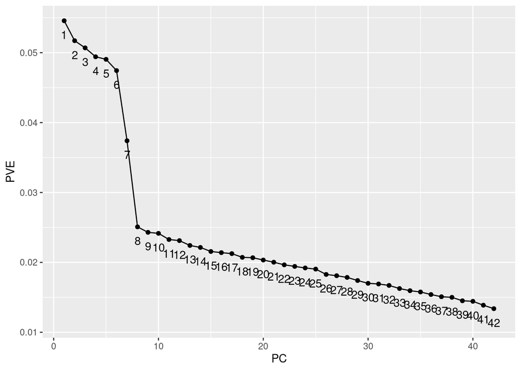

```r
# Screen plot criterion
data.frame(
  PC = my_pca@model$importance %>% seq_along,
  PVE = my_pca@model$importance %>% .[2,] %>% unlist()) %>%
  ggplot(aes(PC, PVE, group = 1, label = PC)) +
  geom_point()+
  geom_line() +
  geom_text(nudge_y = -.002)
```

#### 29 2b.Community.geom_line() **Question**

There are 6 principal components to include before the elbow.

#### 30 2b.Community.PCA **Question**

PCA can be affected by outliers and it does not perform well where complex non-linear patterns often exist.

## Non-metric MultiDimernsional Scaling (NMDS)

### Unconstrained Ordination on Species

```r
# vegetation and environment in lichen pastures from Vare et al (1995)

data("varespec") # species
data("varechem") # chemistry

varespec %>% tibble()
```

```
## # A tibble: 24 × 44
##    Callvulg Empenigr Rhodtome Vaccmyrt Vaccviti Pinusylv Descflex Betupube
##       <dbl>    <dbl>    <dbl>    <dbl>    <dbl>    <dbl>    <dbl>    <dbl>
##  1     0.55    11.1      0        0       17.8      0.07     0        0
##  2     0.67     0.17     0        0.35    12.1      0.12     0        0
##  3     0.1      1.55     0        0       13.5      0.25     0        0
##  4     0       15.1      2.42     5.92    16.0      0        3.7      0
##  5     0       12.7      0        0       23.7      0.03     0        0
##  6     0        8.92     0        2.42    10.3      0.12     0.02     0
##  7     4.73     5.12     1.55     6.05    12.4      0.1      0.78     0.02
##  8     4.47     7.33     0        2.15     4.33     0.1      0        0
##  9     0        1.63     0.35    18.3      7.13     0.05     0.4      0
## 10    24.1      1.9      0.07     0.22     5.3      0.12     0        0
## # … with 14 more rows, and 36 more variables: Vacculig <dbl>, Diphcomp <dbl>,
## #   Dicrsp <dbl>, Dicrfusc <dbl>, Dicrpoly <dbl>, Hylosple <dbl>,
## #   Pleuschr <dbl>, Polypili <dbl>, Polyjuni <dbl>, Polycomm <dbl>,
## #   Pohlnuta <dbl>, Ptilcili <dbl>, Barbhatc <dbl>, Cladarbu <dbl>,
## #   Cladrang <dbl>, Cladstel <dbl>, Cladunci <dbl>, Cladcocc <dbl>,
## #   Cladcorn <dbl>, Cladgrac <dbl>, Cladfimb <dbl>, Cladcris <dbl>,
## #   Cladchlo <dbl>, Cladbotr <dbl>, Cladamau <dbl>, Cladsp <dbl>, …
```

```r
vare.dis <- vegdist(varespec)
vare.mds0 <- monoMDS(vare.dis)
```

#### 32 2b.Community.stressplot()

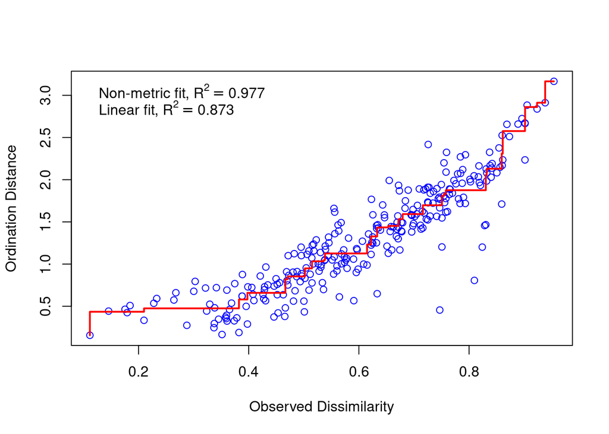

```r
stressplot(vare.mds0)
```

#### 33 2b.Community.stressplot() **Question**

The non-metric fit has a R-squared value that is 0.1 higher than the linear fit which means that it is a better method.

#### 34. 2b.Community.ordiplot()

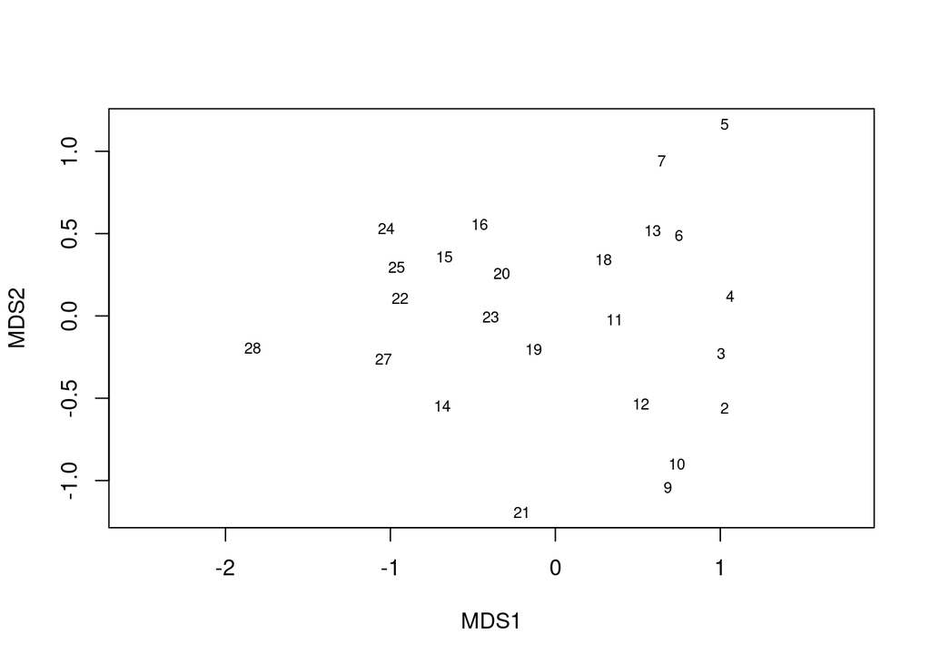

```r
ordiplot(vare.mds0, type = "t")
```

#### 35 2b.Community.ordiplot() **Question**

For the first component, sites 4, 3, 2, and 5 are almost equally dissimilar with 28. For MDS2, sites 21 and 5 are the most dissimilar

#### 36 2b.Community.metaMDS()

```r
vare.mds <- metaMDS(varespec, trace = F)
vare.mds
```

```
##
## Call:
## metaMDS(comm = varespec, trace = F)
##
## global Multidimensional Scaling using monoMDS
##
## Data:     wisconsin(sqrt(varespec))
## Distance: bray
##
## Dimensions: 2
## Stress:     0.1843196
## Stress type 1, weak ties
## Two convergent solutions found after 20 tries
## Scaling: centring, PC rotation, halfchange scaling
## Species: expanded scores based on 'wisconsin(sqrt(varespec))'
```

#### 37 2b.Community.metaMDS()

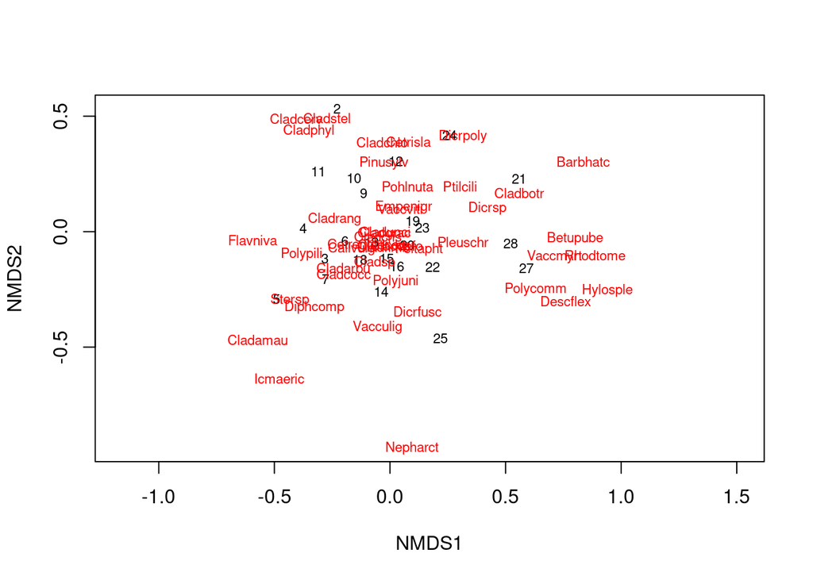

```r
plot(vare.mds, type = "t")
```

#### 38 2b.Community.metaMDS() **Question**

The basic difference is that `metaMDS()` performs several random starts using the functionality of monoMDS() but stops after meeting certain criteria. `monoMDS()` simply starts with the dissimilarities as input and finds two dimensions and uses random configuration to iterate but with no guaranteer convergence.

### Overlay with Environment

#### 39 2b.Community.envfit()

```r
ef <- envfit(vare.mds, varechem, permu = 999)
ef
```

```
##
## ***VECTORS
##
##             NMDS1    NMDS2     r2 Pr(>r)
## N        -0.05039 -0.99873 0.2081  0.075 .
## P         0.68702  0.72664 0.1755  0.137
## K         0.82729  0.56178 0.1657  0.156
## Ca        0.75015  0.66127 0.2811  0.038 *
## Mg        0.69675  0.71731 0.3494  0.013 *
## S         0.27626  0.96108 0.1774  0.136
## Al       -0.83776  0.54603 0.5155  0.001 ***
## Fe       -0.86197  0.50695 0.4001  0.006 **
## Mn        0.80233 -0.59688 0.5322  0.002 **
## Zn        0.66518  0.74668 0.1779  0.132
## Mo       -0.84876  0.52878 0.0517  0.564
## Baresoil  0.87210 -0.48933 0.2494  0.050 *
## Humdepth  0.92636 -0.37664 0.5590  0.001 ***
## pH       -0.79908  0.60123 0.2624  0.042 *
## ---
## Signif. codes:  0 '***' 0.001 '**' 0.01 '*' 0.05 '.' 0.1 ' ' 1
## Permutation: free
## Number of permutations: 999
```

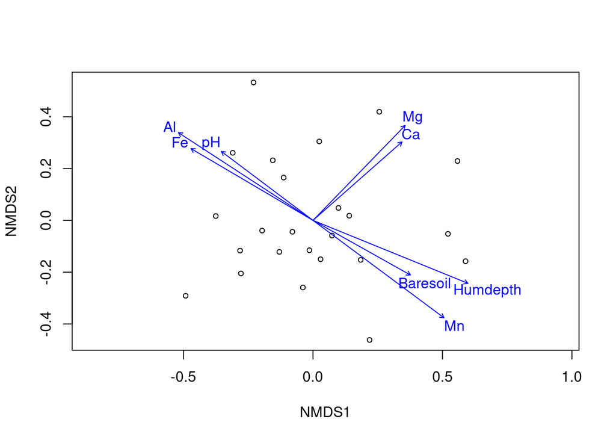

```r
plot(vare.mds, display = "sites")
plot(ef, p.max = 0.05)
```

#### 40 2b.Community.envfit() **Question**

Aluminum and Iron have the strongest negative relationship with NMDS1 that is based on species composition.

#### 41 2b.Community.rdisurf()

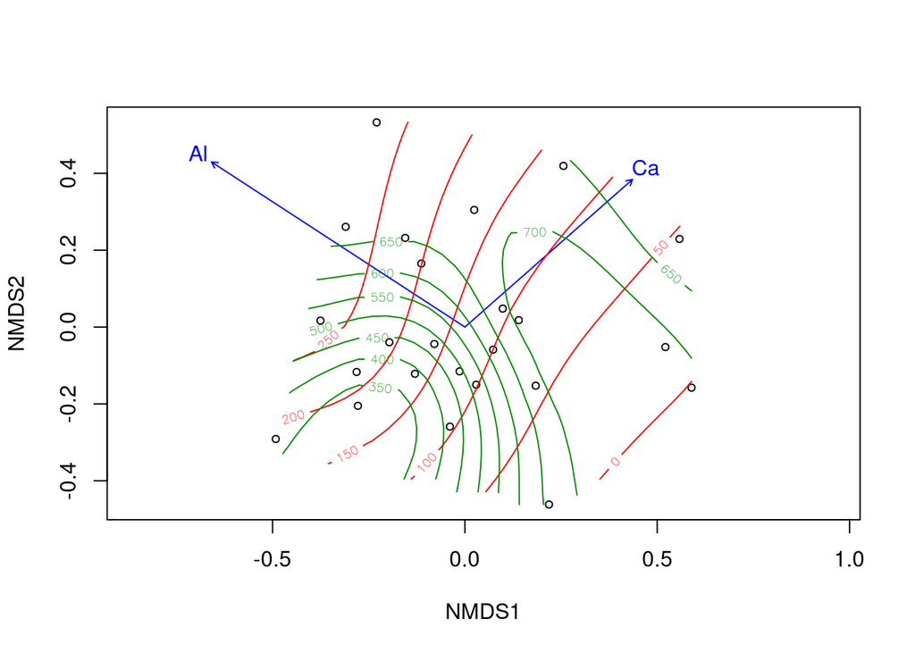

```
##
## Family: gaussian
## Link function: identity
##
## Formula:
## y ~ s(x1, x2, k = 10, bs = "tp", fx = FALSE)
##
## Estimated degrees of freedom:
## 4.2  total = 5.2
##
## REML score: 158.4853
```

```r
ef <- envfit(vare.mds ~ Al + Ca, data = varechem)
plot(vare.mds, display = "sites")
plot(ef)

tmp <- with(varechem, ordisurf(vare.mds, Al, add = TRUE))
ordisurf(vare.mds ~ Ca, data=varechem, add = TRUE, col = "green4")
```

#### 42 2b.Community.ordisurf() **Question**

The ordination surface plot from ordisurf() displays contours of an environmental gradient across sites. It is a more detailed look at an environmental gradient compared to the single blue line vector. This environmental overlay is generated by fitting a GAM where the response is the environmental variable of interest and the predictors are a bivariate smooth of the ordination axes, all given by the formula: Ca ~ s(NMDS1, NMDS2) (Remember each site is associated with a position on the NMDS axes and has an environmental value). We can see from the code that the green4 color contours are for Calcium Ca. Describe in general terms (upper/lower/left/right/middle) where the highest and lowest values are found for Ca with respect to the ordination axes NMDS1 and NMDS2 (ie the ordination axes that describe the most variation of species composition between sites).

350 is the lowest CA value which is found at the lower left of the graph and the highest value of 700 is found opposite that on the upper right of the graph. This means that the lowest Calcium value is found at lower NMSD1 and 2 values but the highest Calcium is found at the higher values of NMDS1 and 2.

### Constrained Ordination on Species and Environment

```r
# this uses another technique cca, or canonical correspondence analysis.
# ordinate on species constrained by three soil elements
vare.cca <- cca(varespec ~ Al + P + K, varechem)
vare.cca
```

```
## Call: cca(formula = varespec ~ Al + P + K, data = varechem)
##
##               Inertia Proportion Rank
## Total          2.0832     1.0000
## Constrained    0.6441     0.3092    3
## Unconstrained  1.4391     0.6908   20
## Inertia is scaled Chi-square
##
## Eigenvalues for constrained axes:
##   CCA1   CCA2   CCA3
## 0.3616 0.1700 0.1126
##
## Eigenvalues for unconstrained axes:
##    CA1    CA2    CA3    CA4    CA5    CA6    CA7    CA8
## 0.3500 0.2201 0.1851 0.1551 0.1351 0.1003 0.0773 0.0537
## (Showing 8 of 20 unconstrained eigenvalues)
```

#### 43 2b.Community.cca() **Question**

Constrained ordination explicitly includes two or more different sets of information into an analysis but unconstrained includes any potential effects by factors which were not included in an analysis.

#### 44 2b.Community.cca()

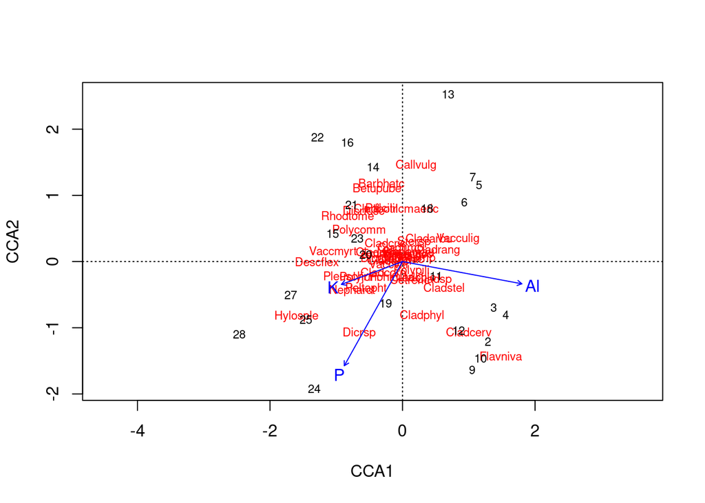

```r
# plot ordination
plot(vare.cca)
```

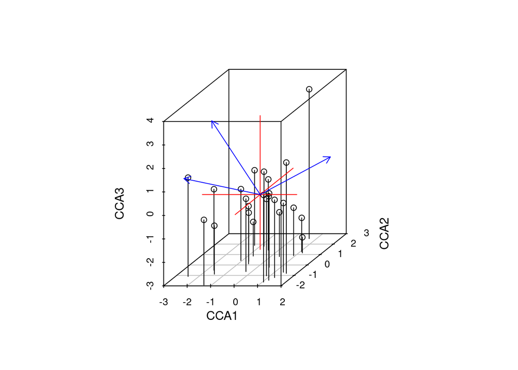

```r
# plot 3 dimensions
ordiplot3d(vare.cca, type = "h")
```

```r
if (interactive()){
  ordirgl(vare.cca)
}
```

#### 45 2b.Community.cca() **Question**

Sites 4 and 28 are most differentiated by CCA1 based on species composition and the environment and the strongest environmental vector is Aluminum.